# NFL_ggplot

Mark Paquette

2023-10-20

# Graph One: Violin Plot

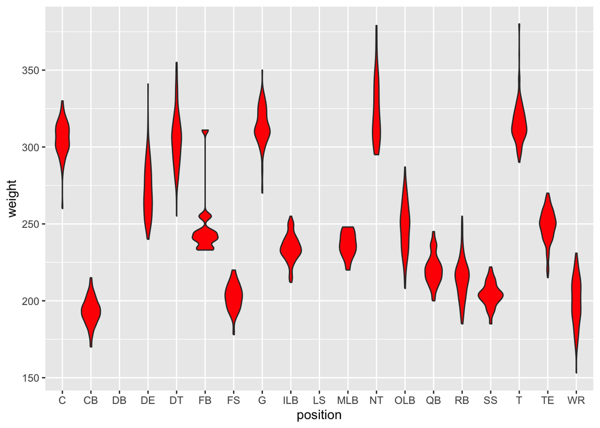

This is a violin plot and helps us visualize a numerical value (weight) vs a categorical value (player position). This graph helps us gain an understanding of both what the most common weights are at a given position while also showing some of the outlier weight (for example a FB who weighs about 310 lbs). This helps us answer questions like what is the typical weight for a Quarterback?

Since it is by organized by position, this type of graph does not really tell us the statistics of the weight as a whole. To find this we would want a plot that only uses weight and not position

# Graph Two: Pie Chart

```
## Defaulting to continuous.
```

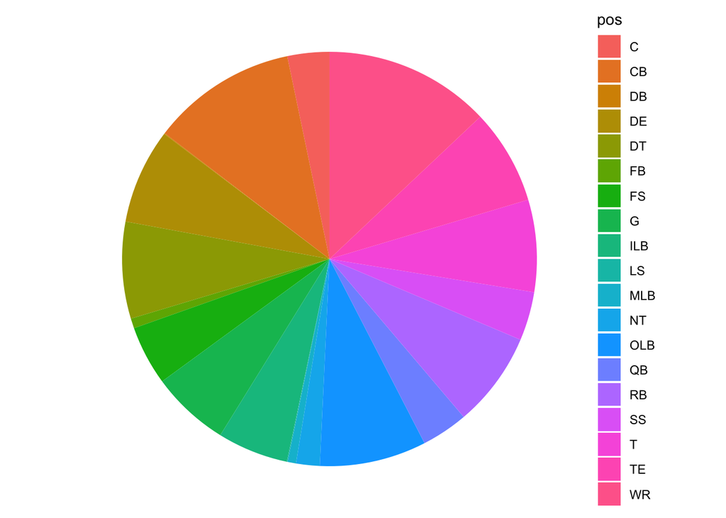

This Pie chart helps us visualize the number of players at each position. This helps us gain an understanding what the most common and least common positions are etc. One thing this is missing is exact numbers. We are not able to tell how many of each position there are, we can only estimate how they compare to one another. To actually represent this, we would need the numerical values for each position labeled on the chart or part of the legend.